# Final Project

Data Science for Biologists, Spring 2021

Richard Demko

## Introduction

I chose this dataset because I am interested in basketball, especially from a stats point of view. There are many variables, ranging from complex to simple. This data is from the late 1970’s through today. Many of the NULLs you see are because the data doesn’t contain certain data before a certain date. I can think of many questions that I could answer. Also, there are some fairly complex metrics that I am not familiar with, which I will enjoy researching. [Data](https://github.com/fivethirtyeight/nba-player-advanced-metrics)

```r
# Reads in the datset
nba_data <- read_csv("https://raw.githubusercontent.com/Rowan-BIOL01301/final_project-rdemko2332/master/Demko_nba-data-historical.csv")
# Reveals the columns of the dataset and some of the data
glimpse(nba_data)
```

```
## Rows: 28,179
## Columns: 42
## $ player_id    <chr> "youngtr01", "huntede01", "huertke01", "reddica01", "col…
## $ name_common  <chr> "Trae Young", "De'Andre Hunter", "Kevin Huerter", "Cam R…
## $ year_id      <dbl> 2020, 2020, 2020, 2020, 2020, 2020, 2020, 2020, 2020, 20…
## $ type         <chr> "RS", "RS", "RS", "RS", "RS", "RS", "RS", "RS", "RS", "R…
## $ age          <dbl> 21, 22, 21, 20, 22, 25, 24, 43, 24, 26, 21, 27, 31, 24, …
## $ team_id      <chr> "ATL", "ATL", "ATL", "ATL", "ATL", "ATL", "ATL", "ATL", …
## $ pos          <chr> "PG", "SF", "SG", "SF", "PF", "SG", "C", "SF", "PF", "C"…
## $ tmRtg        <chr> "NULL", "NULL", "NULL", "NULL", "NULL", "NULL", "NULL", …
## $ franch_id    <chr> "ATL", "ATL", "ATL", "ATL", "ATL", "ATL", "ATL", "ATL", …
## $ G            <dbl> 60, 63, 56, 58, 41, 43, 55, 60, 32, 40, 56, 28, 25, 34, …
## $ Min          <dbl> 2120, 2018, 1760, 1551, 1363, 915, 887, 876, 837, 745, 7…
## $ `MP%`        <chr> "NULL", "NULL", "NULL", "NULL", "NULL", "NULL", "NULL", …
## $ MPG          <dbl> 35.3, 32.0, 31.4, 26.7, 33.2, 21.3, 16.1, 14.6, 26.2, 18…
```

[output cut: 29 more lines]

```r
# Reveals the variables of the dataset
names(nba_data)
```

```
##  [1] "player_id"   "name_common" "year_id"     "type"        "age"
##  [6] "team_id"     "pos"         "tmRtg"       "franch_id"   "G"
## [11] "Min"         "MP%"         "MPG"         "P/36"        "TS%"
## [16] "A/36"        "R/36"        "SB/36"       "TO/36"       "Raptor O"
## [21] "Raptor D"    "Raptor+/-"   "Raptor WAR"  "PIE%"        "AWS%"
## [26] "USG%"        "AST%"        "TOV%"        "ORB%"        "DRB%"
## [31] "TRB%"        "STL%"        "BLK%"        "ORtg"        "%Pos"
## [36] "DRtg"        "2P%"         "3P%"         "FT%"         "3PAr"
## [41] "FTAr"        "Pace +/-"
```

## Question 1

#### Have NBA players started playing less minutes as time goes on, and have any positions specifically decreased in minutes?

### Methods

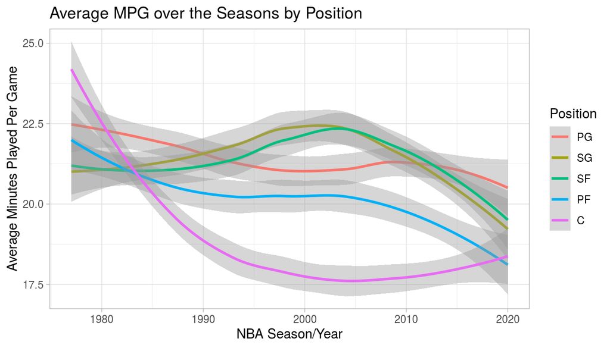

```r
# Creates a variable named common_pos, where it contains the string of the common positions in the NBA
common_pos <- c("PG", "SG", "SF", "PF", "C")
# Pipes the dataset into filter()
nba_data %>%
  # Filters the data where position is common
  filter(pos %in% common_pos) %>%
  # Selects the columns year_id, MPG and pos
  select(year_id,
         MPG,
         pos) %>%
  # Groups the data by year and position
  group_by(year_id,
           pos) %>%
  # Creates a new column named average_minutes that is equal to the mean MPG
  summarise(average_minutes = mean(MPG)) %>%
  # Starts ggplot()
  ggplot() +
  # Maps x to year_id, y to average_minutes and color to a reordered position by common_pos
  aes(x = year_id,
      y = average_minutes,
      color = fct_relevel(pos,
                          common_pos)) +
  # Makes trendlines over time
  geom_smooth() +
  # Renames the legend
  scale_color_discrete("Position") +
  # Changes x and y axis' along with the title
  labs(x = "NBA Season/Year",
       y = "Average Minutes Played Per Game",
       title = "Average MPG over the Seasons by Position") +
  # Changes theme to theme light
  theme_light()
```

## Question 2

#### Have NBA players really started shooting a higher percentage of three-point shots as time goes on?

### Methods

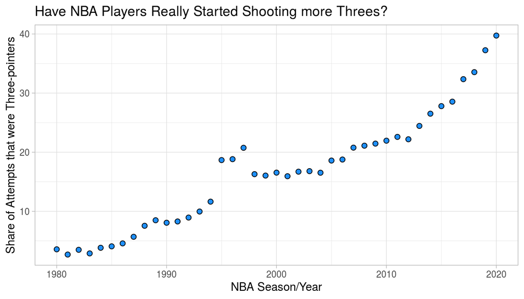

```r
# Pipes dataset into select
nba_data %>%
  # Selects columns year_id and 3PAr
  select(year_id,
         `3PAr`) %>%
  # Filters the data for data before 1980 (no three point before that)
  filter(year_id >= 1980) %>%
  # Groups the data by year
  group_by(year_id) %>%
  # Creates a new column named average_3PA that is equal to the mean of 3PAr
  summarise(average_3PA = mean(as.numeric(`3PAr`))) %>%
  # Starts ggplot()
  ggplot() +
  # Maps x to year_id, x to average_3PA
  aes(x = year_id,
      y = average_3PA) +
  # Makes a scatterplot where the points are fillable circles, filled dodgerblue, outlined in black and size 2
  geom_point(shape = 21,
             fill = "dodgerblue",
             color = "black",
             size = 2) +
  # Changes x and y axis' and changes the title
  labs(x = "NBA Season/Year",
       y = "Share of Attempts that were Three-pointers",
       title = "Have NBA Players Really Started Shooting more Threes?") +
  # Changes theme to theme light
  theme_light()
```

### Answer

Yes, since the NBA added the three point line in the 1979-1980 season, the percentage of three-point shots by players has increased dramatically.

## Question 3

#### Do big men (PF and C) really get rebounds more often, and do smaller players (PG, SG and SF) really get steals more often?

### Methods

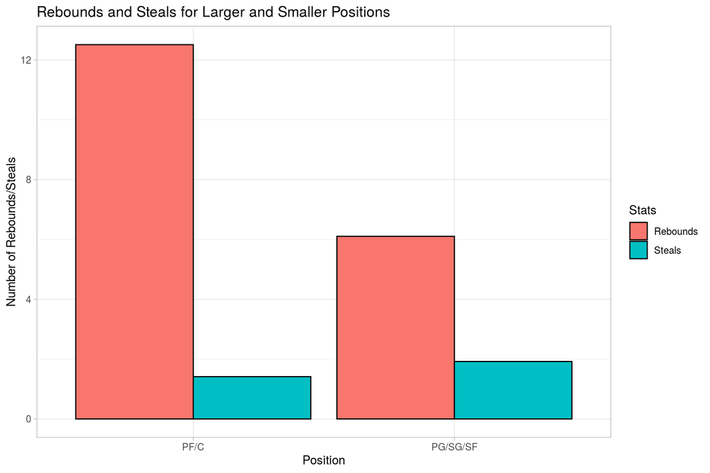

```r
# Defines a variable as the positions PG and SG
small <- c("PG", "SG")
# Pipes dataset into mutate()
nba_data %>%
  # Creates a new column named big_or_small that contains either PG/SG/SF if the position is in the small string, or PF/C if it is not
  mutate(big_or_small = if_else(pos %in% small,
                                "PG/SG/SF",
                                "PF/C")) %>%
  # Selects the columns big_or_small, TRB% and STL%
  select(big_or_small,
         `TRB%`,
         `STL%`) %>%
  # Groups the data by big_or_small
  group_by(big_or_small) %>%
  # Creates two new columns, Rebounds and Steals, each to the average of their respective stat by their position groups
  summarise(Rebounds = mean(as.numeric(`TRB%`)),
            Steals = mean(as.numeric(`STL%`))) %>%
  # Pivots the dataset longer by selecting all columns besides big_or_small, putting the names to a column named Stats and the values to a column named values
  pivot_longer(!big_or_small,
               names_to = "Stats",
               values_to = "values") %>%
  # Starts ggplot()
  ggplot() +
  # Maps x to big_or_small, y to values and fill to Stats
  aes(x = big_or_small,
      y = values,
      fill = Stats) +
  # Makes a bar graph where the bars stand next to each other and are outlined in black
  geom_col(position = "dodge",
           color = "black") +
  # Changes the theme to theme light
  theme_light() +
  # Changes the X and y axis' along with the title
  labs(x = "Position",
       y = "Number of Rebounds/Steals",
       title = "Rebounds and Steals for Larger and Smaller Positions")
```

## Question 4

#### Was Shaq really a worse FT shooter than the average NBA Player?

### Methods

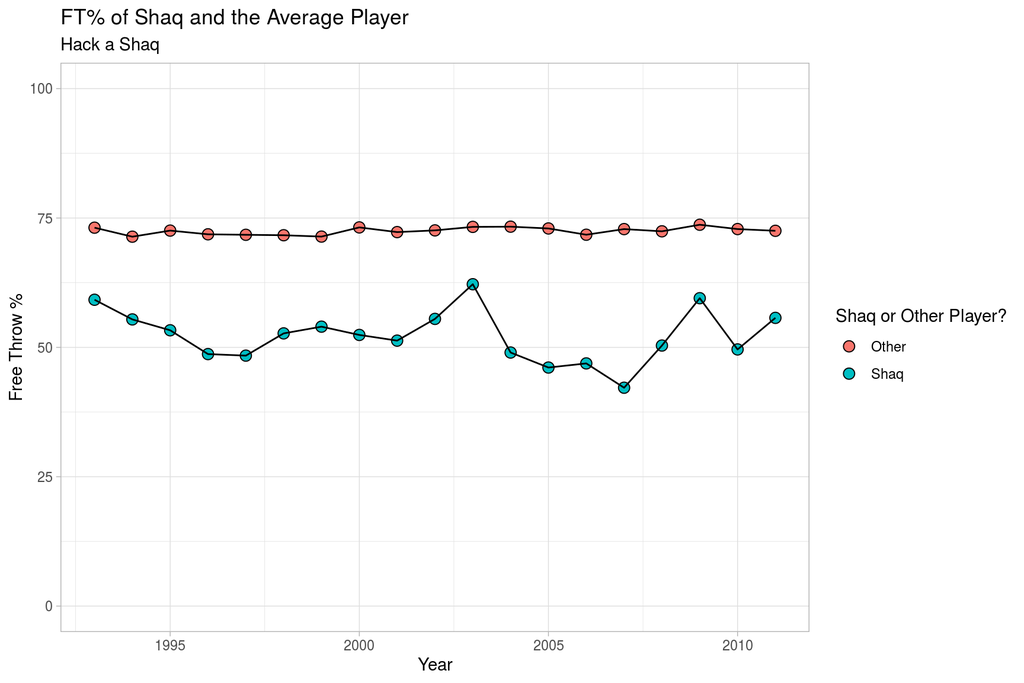

```r
# Defines a variable as a string of years that Shaq played in the NBA
shaq_years <- c(1993:2011)
# Pipes the dataset into Mutate
nba_data %>%
  # Makes a new column named free_throw where if FT% equaled Null, it would be changed to 0, and if not it would stay the same.This is to remove Nulls. The NUlls were introduced because years would appear twice, one for regular season and once for post season. If a team didn't make the post-season, a null was introduced. Doing this and then doing the filter step (see below) allows the regular season data to count without introducing the post-season null
  mutate(free_throw = if_else(`FT%` == "NULL",
                              "0",
                              `FT%`)) %>%
  # Makes a new column named is_shaq, where if name_common equals "Shaquille O'Neal, then it will come up as "Shaq" and if not "Other"
  mutate(is_shaq = if_else(name_common == "Shaquille O'Neal",
                           "Shaq",
                           "Other"))%>%
  # Selects the columns free_throw, year_id and is_shaq
  select(free_throw,
         year_id,
         is_shaq) %>%
  # Filters the data for where free_throw is greater than 0, and where only the years shaq played are counted
  filter(free_throw > 0,
         year_id %in% shaq_years) %>%
  # Groups the data by is_shaq and year_id
  group_by(is_shaq,
           year_id) %>%
  # Makes a new column where average_ft is equal to the mean of free_throw, being counted as a numeric data
  summarize(average_ft = mean(as.numeric(free_throw))) %>%
  # Starts ggplot()
  ggplot() +
  # Maps x to the year, y to average FT% and fill to if the player was Shaq or not
  aes(x = year_id,
      y = average_ft,
      fill = is_shaq) +
  # Makes a scatter plot where shape is a fillable circle, the outline is black and the size is 2
  geom_point(shape = 21,
             color = "black",
             size = 3) +
  geom_line() +
  # Sets the y limit to go all the way from 0 to 100 percent
  ylim(0,
       100) +
  # Changes the legend title
  scale_fill_discrete("Shaq or Other Player?") +
  # Changes the x and y axis', the title and the subtitle
  labs(x = "Year",
       y = "Free Throw %",
       title = "FT% of Shaq and the Average Player",
       subtitle = "Hack a Shaq") +
  theme_light()
```

### Answer

Yes, he averaged a lower (and sometimes MUCH lower) average FT% than the average NBA player during his career… Hack a Shaq.